# covid19

## Partie1: Analyses descriptives

Nous souhaitons effectuer une analyse descriptive des données disponibles à propos du COVID-19 par département en France. Les données considérées proviennent de la base de données “Chiffres-clés” disponible sur le site “data.gouv.fr” auxquelles nous avons ajouté des informations sur la localisation géographique des départements. La période étudiée dans ce projet est celle du 1er Avril 2020 au 14 Avril 2020.

1. Charger le jeu de donnée sous R

```r
data=read.csv2("donnes_covid19_avril_total_par_departement_GPS.csv")
#View(data)
data
```

```
##                  maille_nom duree_jours   latitude    longitude deces_total
## 1                       Ain          15  46.247571    5.1307681         431
## 2                     Aisne          15  49.476920    3.4417368        1641
## 3                    Allier          15  46.311555    3.4167655         138
## 4   Alpes-de-Haute-Provence          15  44.077872    6.2375947          55
## 5           Alpes-Maritimes          15  43.946679    7.1790260         766
## 6                  ArdÃ¨che          15  44.759629    4.5624426         472
## 7                  Ardennes          15  49.762464    4.6285053         118
## 8                   AriÃ¨ge          16  42.932629    1.4434690          13
## 9                      Aube          15  48.156342    4.3732462         618
## 10                     Aude          16  42.956905    2.2593428         478
## 11                  Aveyron          16  44.217975    2.6189273         200
## 12                 Bas-Rhin          15  48.634317    7.5252938        4416
## 13        Bouches-du-RhÃ´ne          15  43.591168    5.3102505        1877
## 14                 Calvados          15  49.121331   -0.4330578         350
```

[output cut: 187 more lines]

2. Présentation du jeu de donnée, puis analyse descriptive

```r
summary(data)
```

```
##   maille_nom         duree_jours       latitude        longitude
##  Length:100         Min.   :15.00   Min.   :-21.12   Min.   :-106.12024
##  Class :character   1st Qu.:15.00   1st Qu.: 44.00   1st Qu.:  -0.03546
##  Mode  :character   Median :15.00   Median : 46.28   Median :   2.26503
##                     Mean   :15.42   Mean   : 43.78   Mean   :  -4.61076
##                     3rd Qu.:15.00   3rd Qu.: 48.34   3rd Qu.:   4.93254
##                     Max.   :20.00   Max.   : 50.57   Max.   :  55.53638
##   deces_total    reanimation_total hospitalises_total  gueris_total
##  Min.   :    0   Min.   :   12.0   Min.   :  113.0    Min.   :   79.0
##  1st Qu.:  135   1st Qu.:  185.5   1st Qu.:  840.8    1st Qu.:  573.5
##  Median :  355   Median :  410.5   Median : 1439.5    Median : 1166.0
##  Mean   : 1047   Mean   : 1000.2   Mean   : 4357.9    Mean   : 2962.3
##  3rd Qu.: 1016   3rd Qu.: 1069.0   3rd Qu.: 3819.5    3rd Qu.: 3238.5
##  Max.   :10285   Max.   :12013.0   Max.   :45669.0    Max.   :23513.0
```

```r
dim(data)
```

```
## [1] 100   8
```

```r
select=c(2,5:8)
min=apply(data[select],2,min)
max=apply(data[select],2,max)
var=max-min
var
```

```
##        duree_jours        deces_total  reanimation_total hospitalises_total
##                  5              10285              12001              45556
##       gueris_total
##              23434
```

```r
apply(data[select],2,sd)
```

```
##        duree_jours        deces_total  reanimation_total hospitalises_total
##           1.173616        1742.547524        1611.107053        7092.236996
##       gueris_total
##        4102.062105
```

```r
apply(data[select],2,mean)
```

```
##        duree_jours        deces_total  reanimation_total hospitalises_total
##              15.42            1046.84            1000.23            4357.94
##       gueris_total
##            2962.33
```

le jeu de donnée a une dimension 100 ligne et 8 colonnes  
le jeu de donnée nous donnes le nombre de:  
deces total (int)  
reanimation total (int)  
hospitalisation total (int)  
gueris total (int)  
en fonction des noms (string) des 100 departements francais.  
Chaque departement possede une localisation GPS indiqué par la longitude et l’altitude.  
On remarqu’il y a 3 départements qui possèdent 0 deces.  
Ces nombres sont prévelés selon une duree_jours qui indique en nombre de jour (int).  
La variables duree_jour est la moins étendu, seulement de 5 (entre 15 et 20) avec un ecart type de 1.1 et moyenne de 15.42. Alors que la variable hospitalises_total est la plus étendu de 46k avec un ecart type de 7k1 et une moyenne de 4k3.  
Il y a des valeurs extrêmes pour deces_total reanimation_total hostpitalises_total et gueris_totral, car la moyenne est toujours au moins 2 fois plus élevé que la medianne  
On représente te les données quantitifs (cumulé) générals à tous les départements, en excluent la durée et les coordonnées gps.

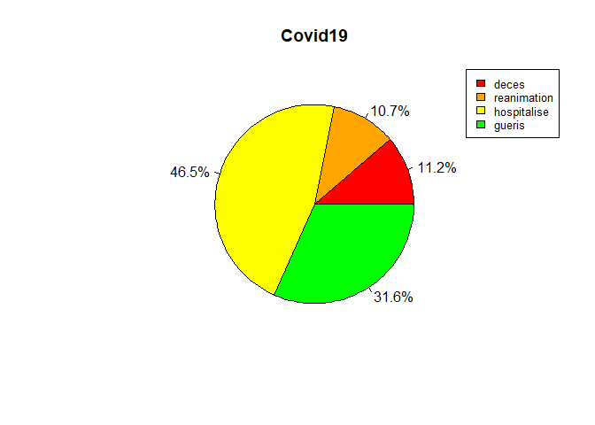

```r
gen=c(sum(data$deces_total), sum(data$reanimation_total), sum(data$hospitalises_total), sum(data$gueris_total))
label=c('deces','reanimation','hospitalise','gueris')
color=c('red','orange','yellow','green')
pourcent<- round(100*gen/sum(gen), 1)
pie(gen, labels=paste(pourcent,"%",sep=""), main = "Covid19",col=color)
legend("topright", label, cex = 0.8,
   fill=color)
```

Il y a autant de décès que de réanimation.  
Il y a 3 fois plus de guéris que de décès.  
Il y a plus d’hospitalisé que de guéris.  
On va maintenant essayer de comparer les departements entre eux  
On trie les données a affiché, et on fais un bloxplot sur les 20 premiers département pour avoir un echantillon

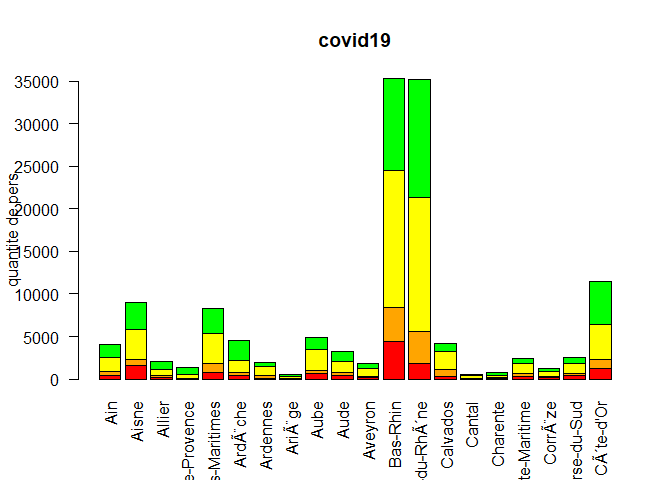

```r
df <- data.frame(t(data[c(5:length(data))]))
colnames(df) <- data[,1]
df=df[c(1:20)]
barplot(height=as.matrix(df), main="covid19", ylab="quantite de pers",beside=FALSE,col=color,las=2)
```

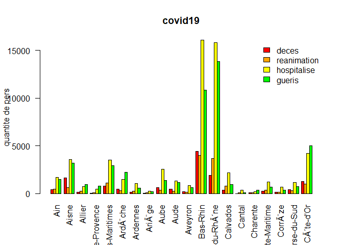

```r
barplot(height=as.matrix(df), main="covid19", ylab="quantite de pers",beside=TRUE,col=color,las=2)
legend("topright", c("deces","reanimation","hospitalise","gueris"), cex=1.0,bty="n",fill=color)
```

La repartiton du covid19 n’est pas proportionnelle entre chaque départements.  
Dans notre echantillon, on remarque qu’en Ariege il y a très peu de victime (-500) comparé aux Bas Rin, et Bouche du Rhone avec +35k chacun.  
Maintenant sur l’ensemble de nos données.

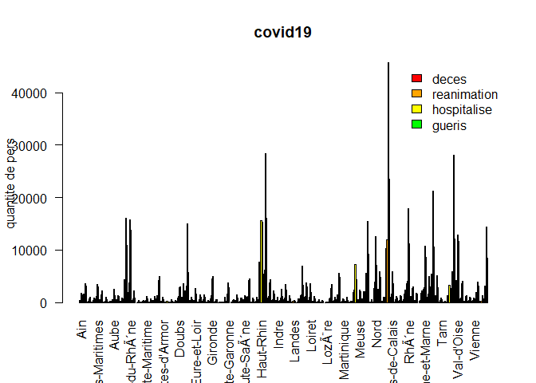

```r
df <- data.frame(t(data[c(5:length(data))]))
colnames(df) <- data[,1]
barplot(height=as.matrix(df), main="covid19", ylab="quantite de pers",beside=TRUE,col=color,las=2,horiz=FALSE)
legend("topright", c("deces","reanimation","hospitalise","gueris"), cex=1.0,bty="n",fill=color)
```

Maintenant on fais un boxplot sur uniquement les victimes du covid19.

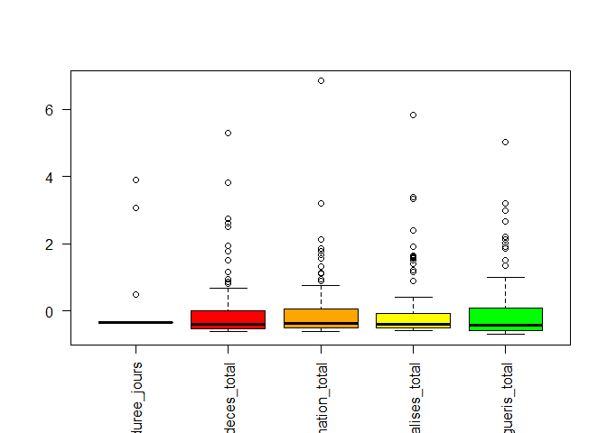

```r
boxplot(scale(data[select],scale=TRUE, center=TRUE),las=2,col=c('pink',color))
```

La variable durée possède des valeurs extreme en petite quantité, elle possede ses 4 quartils équilibré, elle n’est pas interessante.

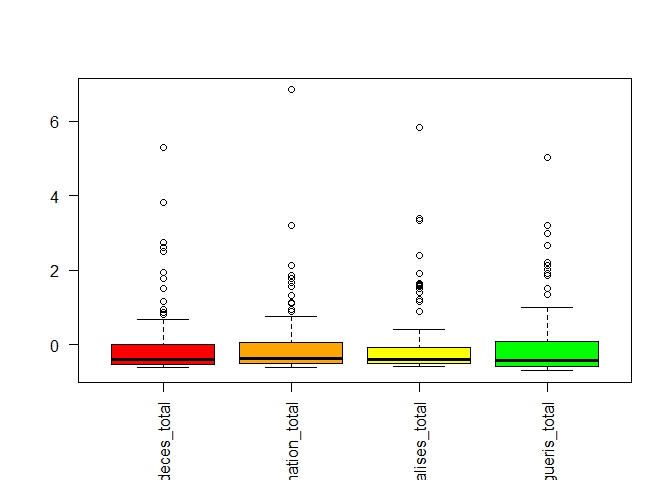

```r
boxplot(scale(data[select][-1],scale=TRUE, center=TRUE),las=2,col=color)
```

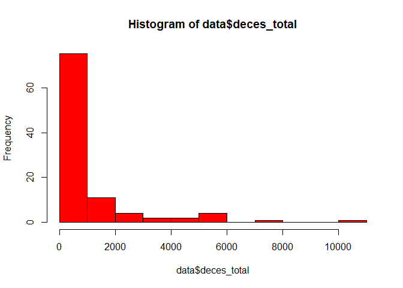

```r
hist(data$deces_total,col = "red")
```

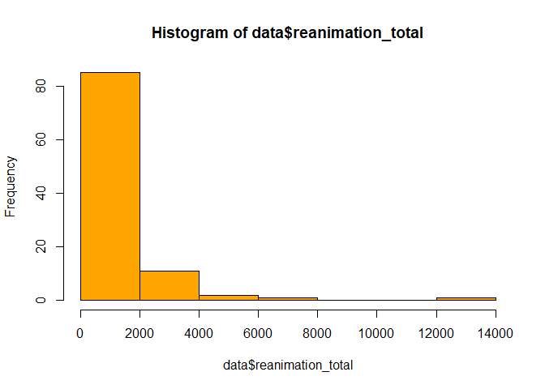

```r
hist(data$reanimation_total,col = 'orange')
```

85% des departements ont moins de 2k reanimation.

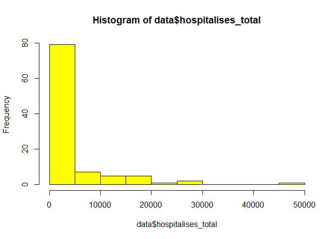

```r
hist(data$hospitalises_total,col = 'yellow')
```

80% des departements ont moins de 5k victimes hosptilalise.

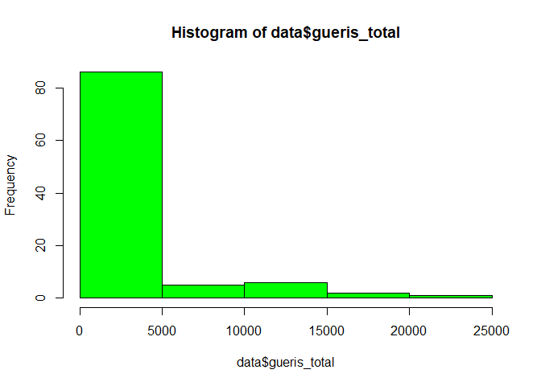

```r
hist(data$gueris_total,col = 'green')
```

85% des departements ont moins de 5k personne gueris.  
Les 4 histogrammes traduient une répartition très concentré, la fréquence est très élevé lorsqu’elle est proche de 0 (la premiere barre), elle forme un groupe.  
En vous inspirant du tutoriel suivant https://www.r-graph-gallery.com/330-bubble-map-with-ggplot2.html qui permet l’affichage de données sur des cartes géographiques à partir de coordonnées GPS (latitude et longitude), afficher chacune des variables «deces_total», «reanimation_total», «hospitalises_total» et «gueris_total» sur une carte géographique. Mettre en avant les données en utilisant des codes couleurs (jaune faible, rouge fort) ou alors en faisant varier les tailles des points. Analyser les résultats obtenus.  
Carte de france metropole (88 départements) sur les décès du au covid19.

```r
# install.packages("viridis")
# install.packages("maps")
# install.packages('mapproj')
library(viridisLite)
library(viridis)
library(ggplot2)
library(dplyr)
library(maps)
library(mapproj)

fr <- map_data("world") %>% filter(region=="France")
head(fr)
```

```
##       long      lat group order region subregion
## 1 9.480371 42.80542   556 39055 France   Corsica
## 2 9.454199 42.65860   556 39056 France   Corsica
## 3 9.473243 42.61557   556 39057 France   Corsica
## 4 9.509375 42.58559   556 39058 France   Corsica
## 5 9.526172 42.55264   556 39059 France   Corsica
## 6 9.556445 42.16094   556 39060 France   Corsica
```

```r
head(data)
```

```
##                maille_nom duree_jours latitude longitude deces_total
## 1                     Ain          15 46.24757  5.130768         431
## 2                   Aisne          15 49.47692  3.441737        1641
## 3                  Allier          15 46.31156  3.416765         138
## 4 Alpes-de-Haute-Provence          15 44.07787  6.237595          55
## 5         Alpes-Maritimes          15 43.94668  7.179026         766
## 6                ArdÃ¨che          15 44.75963  4.562443         472
##   reanimation_total hospitalises_total gueris_total
## 1               446               1691         1457
## 2               602               3563         3204
## 3               266                745          959
## 4                68                452          783
## 5              1088               3484         2939
## 6               282               1473         2249
```

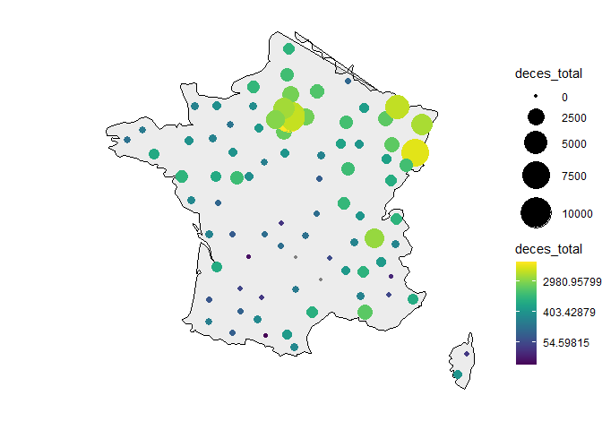

```r
ggplot() +
  geom_polygon(data = fr, aes(x=long, y = lat, group=group), fill="grey", alpha=0.3, color='black')+
  geom_point( data=data, aes(x=longitude, y=latitude, size=deces_total,color=deces_total))+
  scale_size_continuous(range=c(1,12))+
  scale_color_viridis(trans="log")+
  theme_void() +
  ylim(41,51) + xlim(-8,10)+
  coord_map()
```

Carte de france métropole sur les hospitalisations du au covid19.

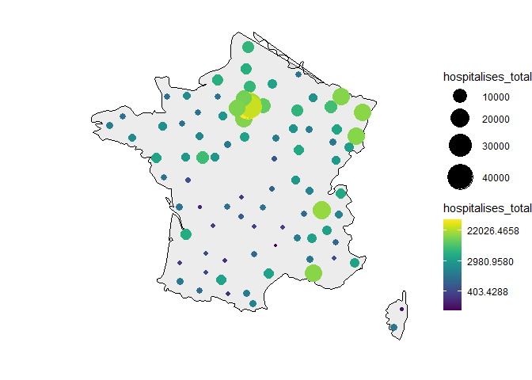

```r
fr <- map_data("world") %>% filter(region=="France")
ggplot() +
  geom_polygon(data = fr, aes(x=long, y = lat, group=group), fill="grey", alpha=0.3, color='black')+
  geom_point( data=data, aes(x=longitude, y=latitude, size=hospitalises_total,color=hospitalises_total))+
  scale_size_continuous(range=c(1,12))+
  scale_color_viridis(trans="log")+
  theme_void() +
  ylim(41,51) + xlim(-8,10)+
  coord_map()
```

Carte de france metropole sur les reanimations du au covid19.

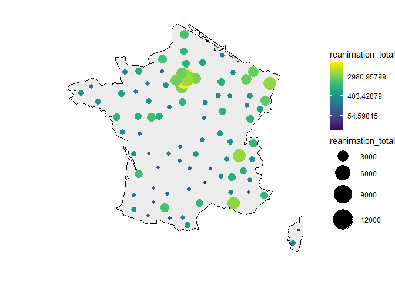

```r
fr <- map_data("world") %>% filter(region=="France")
ggplot() +
  geom_polygon(data = fr, aes(x=long, y = lat, group=group), fill="grey", alpha=0.3, color='black')+
  geom_point( data=data, aes(x=longitude, y=latitude, size=reanimation_total,color=reanimation_total))+
  scale_size_continuous(range=c(1,12))+
  scale_color_viridis(trans="log")+
  theme_void() +
  ylim(41,51) + xlim(-8,10)+
  coord_map()
```

Carte de france metropole sur les guerris du covid19.

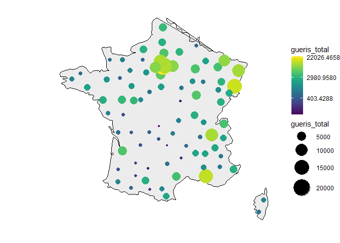

```r
fr <- map_data("world") %>% filter(region=="France")
ggplot() +
  geom_polygon(data = fr, aes(x=long, y = lat, group=group), fill="grey", alpha=0.3, color='black')+
  geom_point( data=data, aes(x=longitude, y=latitude, size=gueris_total,color=gueris_total))+
  scale_size_continuous(range=c(1,12))+
  scale_color_viridis(trans="log")+
  theme_void() +
  ylim(41,51) + xlim(-8,10)+
  coord_map()
```

Les départements possédants le plus de décès, sont correlé positivement au nombre de personne gueris, au nombre de personne en réanimation ainsi qu’au nombre de personne en hospitalisation.  
Ces regions forme des cluster, les plus imposant sont Paris et l’Est de la france, comme Strasbourg, Lyon, Marseilles.  
Paris détiens le plus grand nombre d’hospitalisation et de reanimation, l’unique points jaune de la france pour les cartes correspondantes.  
4. Faire la même chose avec le package leaflet.minichart https://cran.r-project.org/web/packages/leaflet.minicharts/vignettes/introduction.html  
On affiche la carte du monde avec nos données.

```r
# install.packages('leaflet.minicharts')
library(leaflet.minicharts)
library(dplyr)
library(leaflet)
tilesURL <- "http://server.arcgisonline.com/ArcGIS/rest/services/Canvas/World_Light_Gray_Base/MapServer/tile/{z}/{y}/{x}"

basemap <- leaflet(width = "100%", height = "700px") %>%
  addTiles(tilesURL)
datamap <- data %>% select(deces_total,reanimation_total, hospitalises_total, gueris_total)
long=data$longitude
lat=data$latitude

x=basemap %>%
  addMinicharts(
    long,lat,
    chartdata = datamap,
    colorPalette = color,
    width = 20, height = 65
  )
```

Pour le rendu de la carte, executer le fichier main.rmd ou main.html

[interactive chart not shown]

Pour le rendu de la carte, executer le fichier main.rmd ou main.html  
Sur cette carte tous les départements de frances sont représentés (présence de zoom intéractif).  
Les departements outre mer possèdent moins de cas de covid19  
## Partie 2 : Prédiction du nombre de décès  
Dans cette deuxième partie, nous souhaitons étudier et prédire le taux de mortalité des personnes atteintes du COVID-19 (variable «deces_total») selon les variables «reanimation_total», «hospitalises_total» et «gueris_total».  
1. Calculer la corrélation entre les différentes variables et afficher la matrice de corrélation à l’aide du package « corrplot ». Commenter les résultats.  
On fait la matrice de corrélation sur deces_total reanimation_total hospitalises_total et gueris_total.

```r
head(data)
```

```
##                maille_nom duree_jours latitude longitude deces_total
## 1                     Ain          15 46.24757  5.130768         431
## 2                   Aisne          15 49.47692  3.441737        1641
## 3                  Allier          15 46.31156  3.416765         138
## 4 Alpes-de-Haute-Provence          15 44.07787  6.237595          55
## 5         Alpes-Maritimes          15 43.94668  7.179026         766
## 6                ArdÃ¨che          15 44.75963  4.562443         472
##   reanimation_total hospitalises_total gueris_total
## 1               446               1691         1457
## 2               602               3563         3204
## 3               266                745          959
## 4                68                452          783
## 5              1088               3484         2939
## 6               282               1473         2249
```

```r
cor(data[c(5:8)])
```

```
##                    deces_total reanimation_total hospitalises_total
## deces_total          1.0000000         0.8786039          0.9391129
## reanimation_total    0.8786039         1.0000000          0.9688570
## hospitalises_total   0.9391129         0.9688570          1.0000000
## gueris_total         0.9417929         0.9217680          0.9523850
##                    gueris_total
## deces_total           0.9417929
## reanimation_total     0.9217680
## hospitalises_total    0.9523850
## gueris_total          1.0000000
```

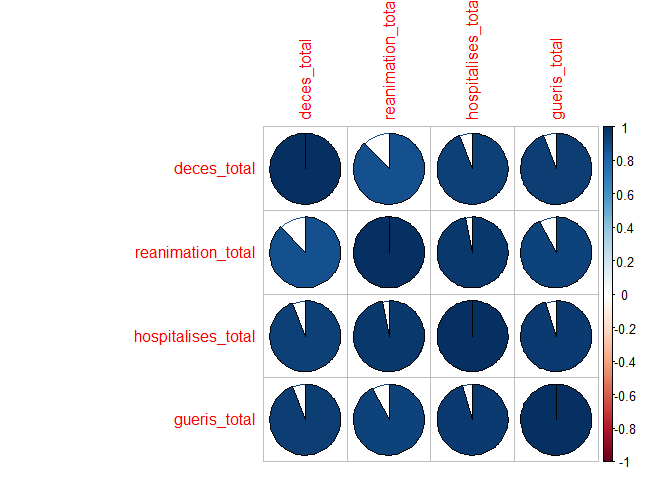

```r
# install.packages("corrplot")
library(corrplot)
mcor=cor(data[c(5:8)])
corrplot(mcor, method="pie")
```

2. Visualiser les nuages de points entre chaque variable et la variable à prédire «deces_total». Quelles sont les variables qui permettent d’expliquer au mieux la variable à prédire ?

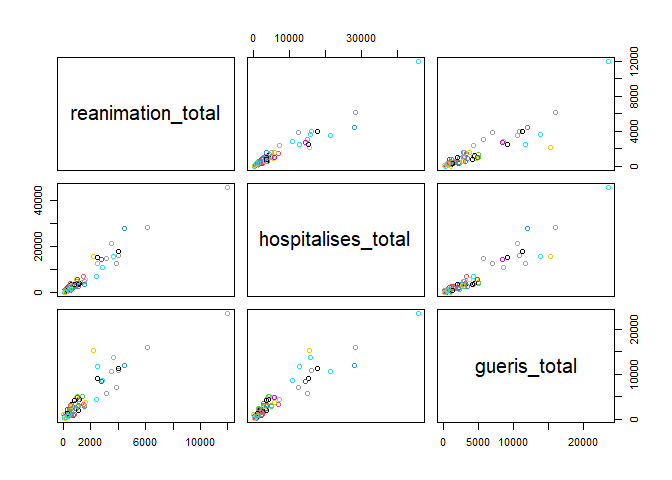

```r
# plot(data$deces_total,data$reanimation_total)
# plot(data$deces_total,data$hospitalises_total)
# plot(data$deces_total,data$gueris_total)
plot(data[c(6:8)], col=data$deces_total)
```

```r
var=data[c(5:8)]
sample=sample.int(n = nrow(var), size = floor(.80*nrow(var)))
train=var[sample,]
test=var[-sample,]
train
```

```
##     deces_total reanimation_total hospitalises_total gueris_total
## 6           472               282               1473         2249
## 56         1000              1128               3790         2907
## 37          300              1563               3711         2873
## 98         1962               522               3908         3142
## 33          763              1368               4530         4941
## 25          826              1078               2838         2937
## 51          476               863               3388         2339
## 53           78               166                340          315
## 59           14               107                259          502
## 21          198               187                979          576
## 38           60                90                367          503
## 16           87                89                216          372
## 20         1283              1004               4180         4981
## 52          260               187               1337          709
```

[output cut: 66 more lines]

```r
length(train$deces_total)
```

```
## [1] 80
```

```r
test
```

```
##    deces_total reanimation_total hospitalises_total gueris_total
## 4           55                68                452          783
## 7          118               254               1061          544
## 11         200               137                850          644
## 13        1877              3681              15822        13834
## 18         141               139                651          350
## 23         113               120                487          284
## 26         948               950               3583         2264
## 27        2208              3129              14985         5659
## 32         104                70                424          192
## 36          39                24                153          999
## 40          27               218                824          785
## 45        7703              2216              15648        15248
## 74        2566              1044               5876         4868
## 76       10285             12013              45669        23513
## 78         154               493               1118          834
## 79         219               409               1269         1106
## 84         268               444               1694         2170
## 92        5804              4439              28084        12035
## 94         633               808               3608         4071
## 97         261               365                846          621
```

```r
length(test$deces_total)
```

```
## [1] 20
```

4. Réaliser une régression linéaire entre les variables explicatives «reanimation_total», «hospitalises_total», «gueris_total», et la variable à expliquer «deces_total» sur l’ensemble d’apprentissage. Afficher et commenter les quatre graphiques de diagnostic.  
Régression lineaire entre la variable à prédire deces_total et la variable explicative reanimation_total.

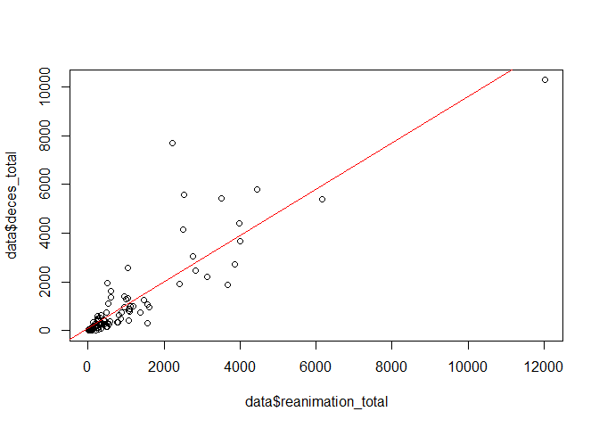

```r
lm_reanimation= lm(deces_total ~ reanimation_total , data=data)
plot(data$reanimation_total, data$deces_total)
abline(lm_reanimation, col="red")
```

Régression linéaire entre la variable à prédire deces_total et la variable explicative hospitalises_total.

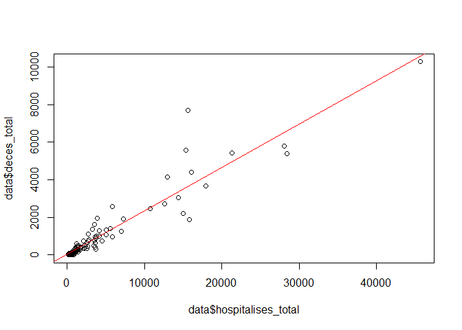

```r
lm_hospitalises= lm(deces_total ~ hospitalises_total , data=data)
plot(data$hospitalises_total, data$deces_total)
abline(lm_hospitalises, col="red")
```

Régression linéaire entre la variable à prédire deces_total et la variable explicative gueris_total.

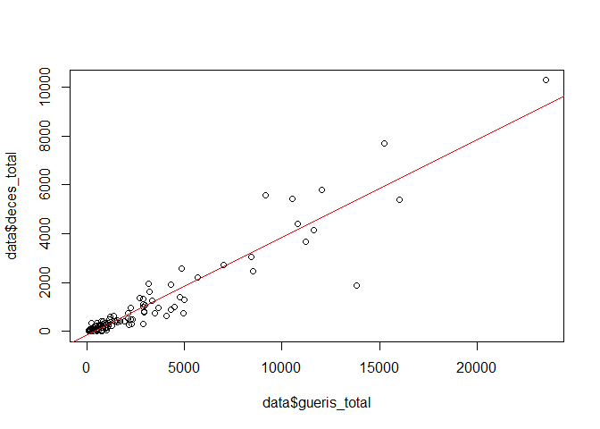

```r
lm_gueris= lm(deces_total ~ gueris_total , data=data)
plot(data$gueris_total, data$deces_total)
abline(lm_gueris, col="red")
```

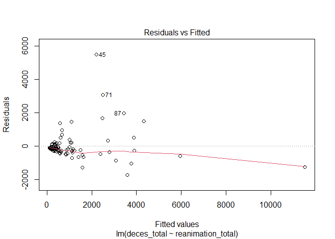

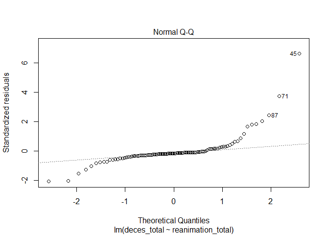

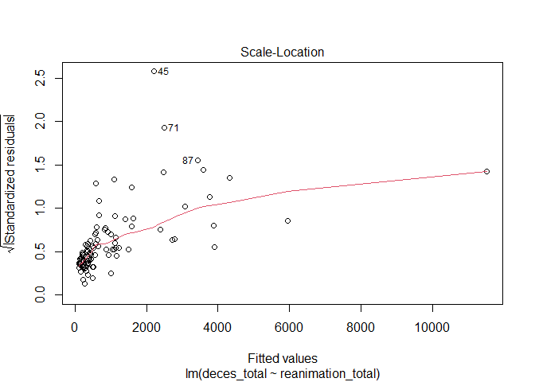

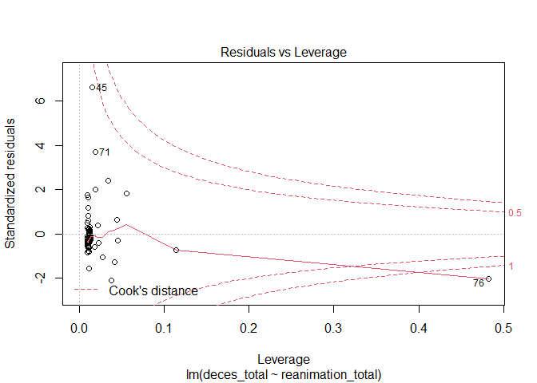

```r
plot(lm_reanimation)
```

On analyse en détails la régression linéaire sur gueris_total.

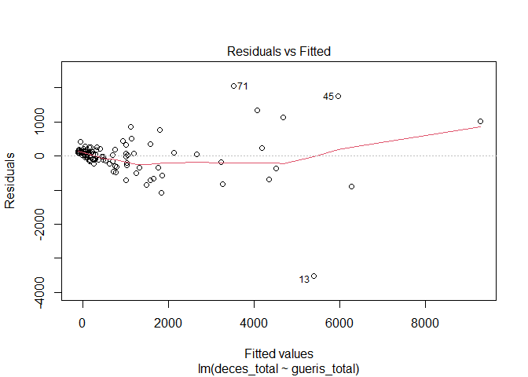

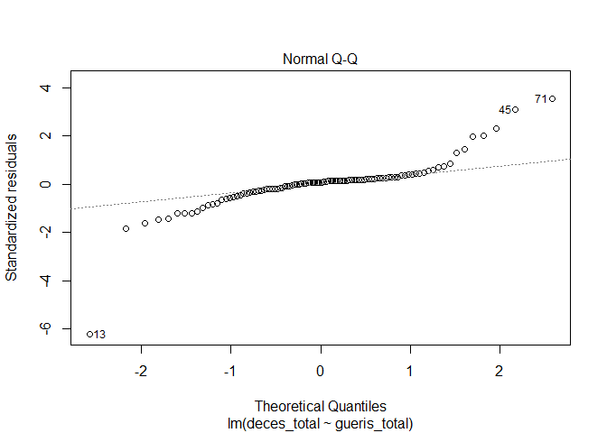

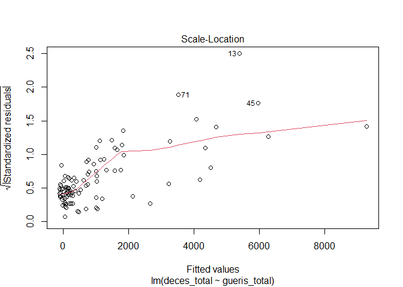

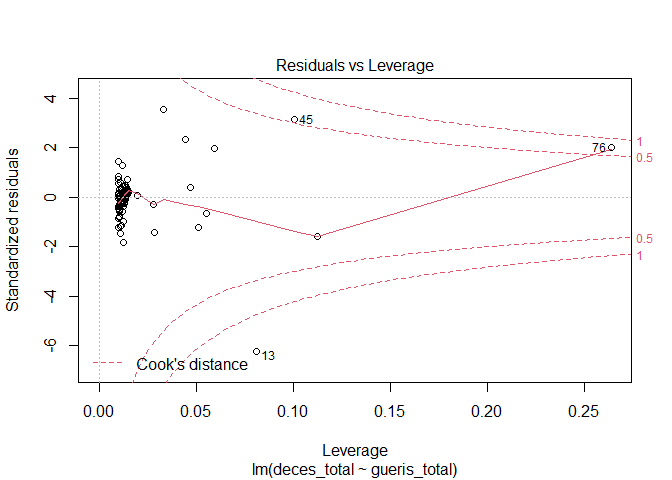

```r
plot(lm_gueris)
```

On analyse en détails la régression linéaire sur hospitalises_total

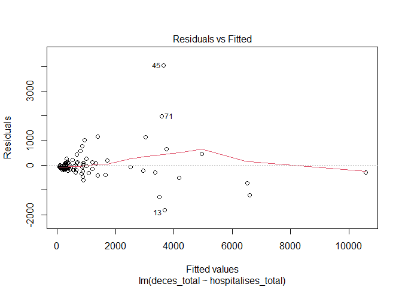

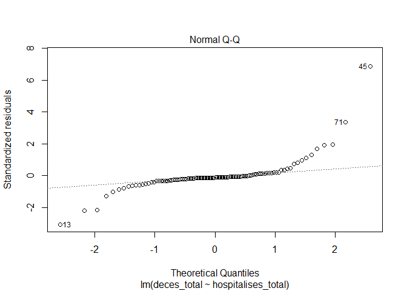

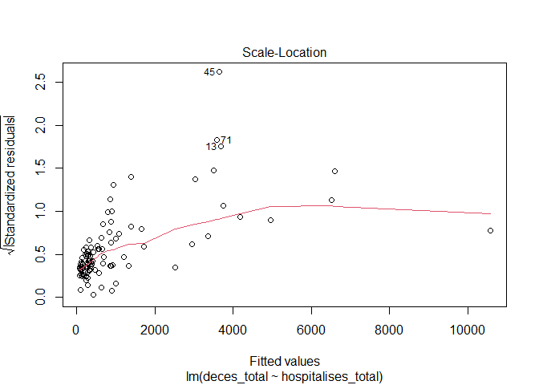

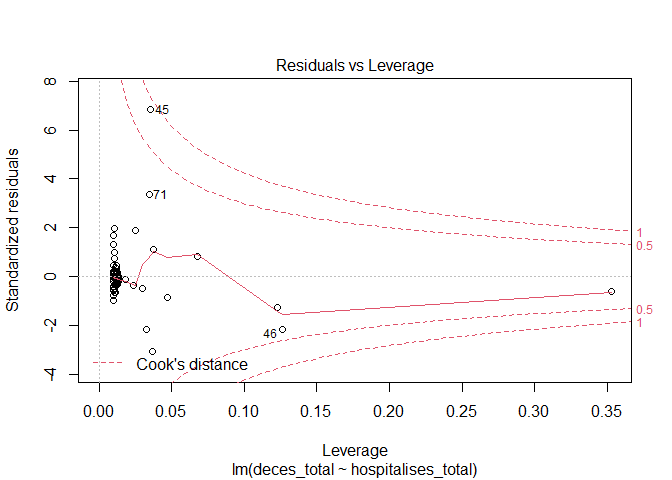

```r
plot(lm_hospitalises)
```

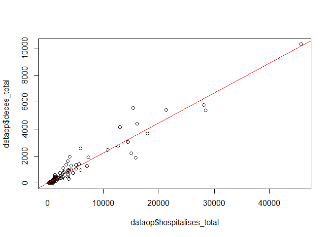

```r
dataop=data[-c(45),]
lm_hospitalises= lm(deces_total ~ hospitalises_total , data=dataop)
plot(dataop$hospitalises_total, dataop$deces_total)
abline(lm_hospitalises, col="red")
```